# PhaseRetrieval

## Table of Contents:

- 00. PhaseRetrieval
  - 00.1. Source code
  - 00.3. Requirements
  - 00.4. License
- 1. Image processing for phase retrieval
  - 1.0. Glossary
  - 1.1. Processing in the object domain
    - 1.1.1. Initialisation
    - 1.1.2. Background subtraction
    - 1.1.3. Centering using watershed algorithm
    - 1.1.4. Re-sampling
  - 1.2. Processing in the Fourier domain
    - 1.2.1. Initialisation
    - 1.2.2. Zero-padding and centering
    - 1.2.3. Subtraction of background
    - 1.3.4. Renormalisation (Parseval's theorem)
  - 1.4. Saving processed images
- 2. Phase retrieval
  - 2.1. Phase retrieval from two intensity measurements
  - 2.2. Oversampling requirements
  - 2.3. Gerchberg-Saxton algorithm
  - 2.4. Gerchberg-Saxton algorithm with extrapolation
- 3. References

```python
#remove_cell
import sys
import glob,os
from matplotlib import pyplot as plt
import numpy as np


datapath = '/Users/Pavel/Documents/repos/PhaseRetrieval/docs/data'
sourcepath = '/Users/Pavel/Documents/repos/PhaseRetrieval/'

sys.path.insert(0,sourcepath)
sys.path.insert(0,datapath)



#automatically track changes in the source code
%load_ext autoreload
%autoreload 2
```

# PhaseRetrieval

Author: Dr. Pavel Kliuiev

PhaseRetrieval is a Python-based framework for solution of the phase problem widely encountered in optics. The framework incorporates the full workflow for phase retrieval: image pre-processing, reconstruction of images by phase retrieval algorithms and post-processing of reconstructed images (such as image registration).

[figure not shown]

The phase retrieval problem is a mathematical problem of recovering an unknown object distribution (an unkwown function) from the known modulus of its Fourier transform. Phase retrieval algorithms (Gerchberg-Saxton-1972) make use of available information (such as real- or complex-valuedness of the object or its low-resolution optical image). The problem is widely encountered in imaging and signal processing and its applications range from adaptive optics for large space telescopes and 3D microscopic imaging of cells to imaging through turbulent atmosphere and visualisation of the valence orbitals of organic molecules.

Section "Image processing for phase retrieval" lists typical steps needed for processing of raw images prior to the application of phase retrieval algorithms.

Section "Phase retrieval" provides a detailed description of the steps for the recovery of the object distributions either when only Fourier modulus is available or in case of availability of both the Fourier- and the object-domain data.

## Source code

The source code is located under https://github.com/pkliui/PhaseRetrieval

## Requirements

The software was tested using the following versions of the packages:

- ddt 1.3.1
- numpy 1.15.4
- python 3.6.8
- pandas 0.24.2
- scipy 1.1.0
- scikit-image 0.16.2

## License

The source code is released under GNU General Public License v3.0

# Image processing for phase retrieval

The scheme below show typical image processing steps need to be done [Kliuiev-2016, Kliuiev-2018] prior to application of phase retrieval algorithms. It is assumed that both object- and Fourier-domain images are available. If only Fourier-domain images are available, then step 5 "re-sampling and energy conservation" becomes redundant.

In the following, I demonstrate how each of these steps is performed in PhaseRetrieval framework.

[figure not shown]

## Glossary

We explicitly distinguish between **"distribution" and "image"**.

**Object's distribution** refers to the non-zero-valued discrete representation of the physical distribution of an object limited to the object's physical boundaries.

**Object's image**, on the contrary, refers to a discrete representation of the physical distribution of an object as captured by an imaging system. That is an image of an object may contain not only the distribution of the object itself, but also the surrounding areas (which do not belong to the obejct distribution). In phase retrieval, one of the requirements for the solution of the phase problem is that the object distribution is surrounded by a well-known transmission function. This is typically done by a certain experimental arrangement. If the transmission function is set to zero, then, in the *object's image* all pixels around the *object's distribution* are zero-valued pixels.

Similar considerations apply to **Fourier distribution** and **Fourier image**. We refer to a non-zero-valued discrete representation of the diffraction pattern whose physical extent is limited by the numerical aperture or the detector area as **Fourier distribution**. If the Fourier distribution is padded with zeros, for example, then it is referred to as **Fourier image**.

## Processing in the object domain

### Initialisation

> We start by importing `RSpaceImage` class for object-domain images.

```python
from PhaseRetrieval.classes.rspaceimage import RSpaceImage
print(RSpaceImage.__init__.__doc__)
```

```
        Initializes the object-domain image class

        ---
        Parameters
        ---
        filename: str, optional
            Path used to load the image.
            If None, an empty class is created.
            If `image` argument is provided, the image will be initialized from the `image` argument.
            Default is None.
        delimiter: str, optional
            Delimiter used in the csv file
            Delimiter needs to be specified if the data are to be loaded from a csv file.
            If None, then it is assumed that the data are to be loaded from a tif file.
            Default is None.
        image : ndarray, optional
            2D array to initialize the image.
            If None, an empty class is created.
            Default is None.
        image_apodization_filter: ndarray, optional
            2D array to initialize the thresholded version of the image (i.e. image apodization filter).
            If None, an empty class is created.
            Default is None.
```

#### Read data

> As soon as the class is loaded, an image can be read by specifying the following keyword arguments in `RSpaceImage` class: `filename`, `delimiter`.

> The loaded image can be plotted using `plot_image` method of `RSpaceImage`class. To zoom in to the image, set the keyword argument `zoom` to any float > 1.

```
Object domain: Input image was read
```

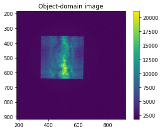

```python
rs = RSpaceImage(filename=os.path.join(datapath,'rs35.csv'),
                 delimiter='\t')
rs.plot_image(zoom=1.5)
```

#### Rotation and flipping

Sometimes, in the data acquisition process, mutual orientation of the object- and Fourier-domain images can be changed (i.e. horizontal and vertical axes in object-domain images can be either flipped or rotated with respect to those in Fourier-domain images). Hence the data must be rotated and/or flipped.

> Rotation is done by `rotate_image`method by setting
> - `times_rot=1`to rotate only once
> - `estimate_only` to `True` if it is only required to estimate how the image will look like if rotated
> - `estimate_only` to `False` to perform the actual rotation.

> Counter-clockwise rotaion by default. To change the direction of the rotation, either set the keyword argument `axes`to `(1,0)` or just set the number of rotations to `times_rot=3`.

```
Object-domain: Input image was rotated
```

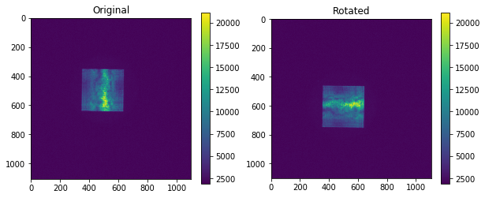

```python
rs.rotate_image(times_rot=1,
                estimate_only=False,
                plot_progress = True)
```

> Flipping is done using `flip_image`method. The method flips the image upside-down by default. To flip left-right, set the keyword argument `axis`to `0`. Set `estimate_only`to `True`to only estimate how the image will look like if flipped and to `False`to perform the flipping.

```
Object-domain: Image was flipped
```

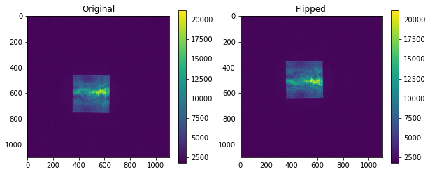

```python
rs.flip_image(estimate_only=False, plot_progress = True)
```

### Background subtraction

Background subtraction for phase retrieval may involve image denoising and/or elimination of some spurious features. A common method for noise reduction is averaging images over multiple exposures. This is a very effective method as it reduces noise without compromising detail and increases the signal-to-noise ratio (SNR).

In the following examples, it is demonstrated how to perform image denoising only. Images used here were already denoised by averaging over multiple exposures. However, they still have a quasi-constant background which must be subtracted prior to phase retrieval. This is because the presence of this background is not consistent with the constraints applied in the object and Fourier domains.

Namely, one may expect that by adding noise in Fourier domain we simply add noise to the corresponding object-domain distribution. In phase retrieval, however, the corresponding object distribution is confined to a certain area surrounded by zeros (or any other well-defined transmission function), which is called object support. Multiple iterations between these two domains and the application of the support constraint do not allow noise in Fourier domain to get translated into noise in the object-domain. As a result, noise in both domains must be subtracted to eliminate this disagreement.

> As mentioned above, we assume that the background distribution is quasi-constant throughout the whole image. For its subtraction, we use `subtract_background`method of class `RSpaceImage`.

> Set `estimate_only=True` to estimate how the image will look like after the background subtraction. Plotting in logarithmic scale makes it easier to see whether the set counts' value is high enough.

> As soon as one is satisfied with the result, set `estimate_only=False` and the specified number of counts will be subtracted from the image.

```
Object domain: Plotted in log scale
```

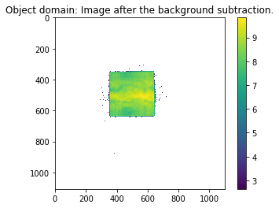

```
Object domain: Background of 2450 counts was subtracted.
```

```python
rs.subtract_background(counts=2450,
                       estimate_only=False,
                       log_scale=True,
                       plot_progress = True)
```

### Centering using watershed algorithm

The next step is to perform centering of the image in the computational domain.

> The centering can be done using `centre_image_watershed` method of class `RSpaceImage`.

```python
print(rs.centre_image_watershed.__doc__)
```

```
        Centers the object-domain image using watershed algorithm (the existence of only a single blob is assumed).
        Finds its physical linear pixel size and saves this information into image's metadata.
        Completes zero-padding of the original image to a specified linear number of pixels
        Applies an apodization filter to smooth boundaries of the object distribution (optional)

        ---
        Parameters
        ---
        linear_object_size: float, optional
            Physical linear size of the (non-zero-valued) input object distribution, in m.
            Default is 100 micrometer.
        npixels_pad: int, optional
            Linear number of pixels in the zero-padded object-domain image.
            Default is 2000.
        apodization: bool, optional
            If True, the boundaries of the object distribution will be smoothed using Gaussian filter
            with standard deviation = 3 pixels and truncation of the filter's boundaries to 2
            (fixed at the moment, but may/should be changed in the future)
            Default is False
        plot_progress: bool, optional
            Plot images.
            Default is False
```

The steps performed by this method include:

- Computing distance transform of the background-free image
- Using this image as an input to watershed algorithm
- Zero-padding to a desired number of pixels
- Finding the centre of mass of the padded watershed image
- Centring

Note that typically distance transform is computed for binary images. This is because distance transform is very sensitive to small changes in the image's intensity. For example, adding salt-and-pepper noise will significantly corrupt even a binary image. Here we use `scipy`'s `ndi.distance_transform_edt` function to compute Eucledian distance transform of the backgorund-free image. This function computes the Eucledian distance from non-zero pixels to the nearest zero pixels (upon background subtraction we set all affected "background" pixel values to zero). Hence distance transform allows to roughly estimate the object's boundaries.

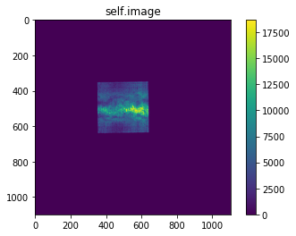

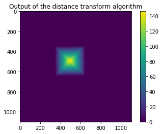

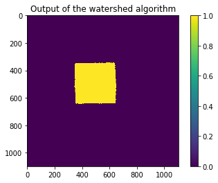

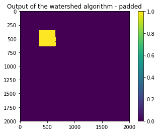

```
Object domain: Input and watershed images were padded to  2000 X 2000 pixels.
```

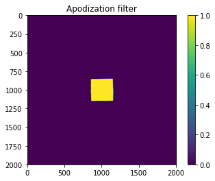

```
Object domain: Image centred. Apodization filter was applied. Linear pixel size is  0.0 nm
```

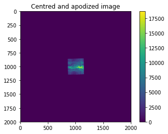

```python
rs.centre_image_watershed(linear_object_size=100e-6,
                          npixels_pad=2000,
                          apodization=True,
                          plot_progress = True)
```

### Re-sampling

The pixel sizes in the object image, $\Delta r$ [m], and Fourier image, $\Delta k$ [rad/m], are connected as

$\Delta r \Delta k = \frac{2\pi}{N}$, (1)

where $N$ is the linear pixel number. If one aims at using both object- and Fourier-domain images in phase retrieval algorithms, equation (1) must be fulfilled. Typically, this is not the case for raw data and either of images must be resampled to ensure correct application of the discrete Fourier transform.

#### New number of pixels

Let's assume the pixel sizes of unprocessed object- and Fourier-domain images are $\Delta r_{oo}$ and $\Delta k_{FF}$, respectively. These pixel sizes are set by experimental conditions, such as optical magnification, and hence are fixed. Object distribution is confined to $N_{oo}\times N_{oo}$ pixels area and is surrounded by a zero-padded region. The total area of the object-domain image is thus sampled with $N_o\times N_o$ pixels ($N_o > N_{oo}$) which is set either by imaging conditions or by user choosing an appropriate width of the zero-padded region.

In Fourier domain, the size of the non-zero-valued area is set by the field of view of the imaging system to $N_{FF} \times N_{FF}$ pixels. If we set $N_{o}$ such that $N_{o}=N_{FF}$, then, according to equation (1), the effective size of the pixel in Fourier domain should be $\Delta k_\textrm{eff} = \frac{2\pi}{N_{o}\Delta r_{oo}}$. Hovewer, typically, $\Delta k_\textrm{eff} \neq \Delta k_{FF}$, as both $\Delta r_{oo}$ and $\Delta k_{FF}$ are set by experimental conditions which in most cases cannot be the same. Similarly, if $N_{o}=N_{FF}$, the effective size of the pixel in the object domain is $\Delta r_\textrm{eff} = \frac{2\pi}{N_{o}\Delta k_{FF}}$ and, typically, $\Delta r_\textrm{eff} \neq \Delta r_{oo}$.

The data must be thereby re-sampled in either domain to fulfill equation (1). Here, $D = \left[\frac{\Delta r_\textrm{eff}}{\Delta r_\textrm{oo}}\right]>1$, which we call the downsampling ratio and $[]$ denote rounding to the nearest integer, as not necessarily $\frac{\Delta r_\textrm{eff}}{\Delta r_\textrm{oo}} \in \mathrm{Z}$.

Because, in our case, object-domain images have got less high-frequency features and thus should be less prone to re-sampling-induced artifacts, we re-sample object-domain images by `resize`method implemented in `scikit-image` with `anti-aliasing` argument set to `True`.

After re-sampling, the object-domain image is zero-padded to a new linear number of pixels:

$N = \left[ \frac{2\pi}{D * \Delta r_{oo} * \Delta k_{FF}} \right]$ (2).

> Resampling is done with `resample_image`method of class `RSpaceImage`. Returns final linear number of pixels in the object domain.

```python
print(rs.resample_image.__doc__)
```

```
        Resamples object-space image to equalise its pixel size to the one set by
        digital Fourier transform and the pixel size in the experimental Fourier-space image

        ---
        Parameters
        ---
        fieldofview: int, optional
            One half of field of view in Fourier-space, in degrees
            Default is ±17°, i.e. fieldofview = 17
        npixels_kspace: int, optional
            One half of linear number of non-zeros-valued pixels in experimental Fourier-space image to be used together with the real-space image
            (= corresponds to the linear number of pixels within the 1/2 of field of view)
            Default is 500
        pixelsize_dr0: int, optional
            Pixel size in experimental object-domain image, in m.
            If it is None, the value will be read from metadata (saved to metadata after centering and segmentation of the image).
            If the value in metadata is None, there will be an error message.
            Alternatively, one can set the pixel size manually.
            Default is None.
        lambd: float, optional
            Wavelength of light, in m
            Default is 880e-9
        estimate_only: bool, optional
            False will irreversibly resample the input image.
            True will only estimate the downsampling ratio.
            Default is True.
        ---
        Returns
        ---
        npixels_final : int
            Final linear number of pixels in the object-domain image
```

```python
rs.resample_image(fieldofview = 17,
                 npixels_kspace = 726/2,
                 pixelsize_dr0 = 426e-9,
                 lambd = 880e-9,
                 estimate_only = False)
```

```
Object domain: Input image shape is  2000 X 2000
Object domain: Image was resampled and its current shape is (2000, 2000)
Object domain: Image was resampled with the downsampling ratio = 1.0 and zero-padded to npixels_final X npixels_final= 2564 X 2564 pixels
```

```
2564
```

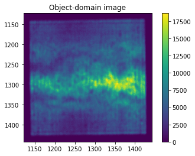

```python
rs.plot_image(zoom=8)
```

## Processing in the Fourier domain

### Initialisation

```python
from PhaseRetrieval.classes.kspaceimage import KSpaceImage
print(KSpaceImage.__init__.__doc__)
```

```
        Initializes Fourier-domain image class

        ---
        Parameters
        ---
        filename: str, optional
            Path used to load the image.
            If None, an empty class is created.
            If `image` argument is provided, the image will be initialized from the `image` argument.
            Default is None.
        delimiter: str, optional
            Delimiter used in the csv file
            Delimiter needs to be specified if the data are to be loaded from a csv file.
            If None, then it is assumed that the data are to be loaded from a tif file.
            Default is None.
        image : ndarray, optional
            2D array to initialize the image.
            If None, an empty class is created.
            Default is None.
        renorm_factor : float
            Renormalisation factor to fulfill Parseval's theorem
            If None, an empty class is created.
            Default is None.
```

#### Read data

> As soon as the class is imported, an image can be read by specifying the following keyword arguments: `filename`, `delimiter`.

> Currently, only csv and tif formats are supported.

> The loaded image can be plotted using `plot_image` method of `KSpaceImage`class. To zoom into the image, set the keyword argument `zoom` to any float > 1. Logarithmic scale is by setting `log_scale`to `True`.

```
Fourier domain: Input image was read
```

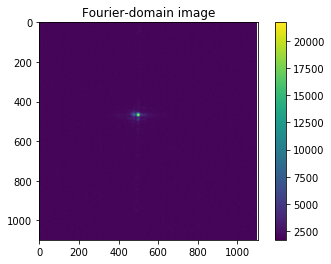

```python
ks = KSpaceImage(filename=os.path.join(datapath,'ks35.csv'),
                 delimiter='\t')
ks.plot_image(zoom=1,
              log_scale = False)
```

#### Rotation and flipping

> Rotation is done by `rotate_image` method by setting
> - `times_rot=1`to rotate only once
> - `estimate_only` to `True` if it is only required to estimate how the image will look like if rotated
> - `estimate_only` to `False` to perform the actual rotation.

> Counter-clockwise rotaion by default. To change the direction of the rotation, either set the keyword argument `axes`to `(1,0)` or just set the number of rotations to `times_rot=3`.

```
Fourier domain: Input image was rotated
```

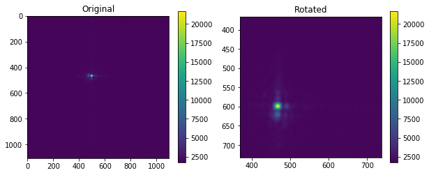

```python
ks.rotate_image(times_rot=1,
                zoom=3,
                estimate_only=False,
                plot_progress = True)
```

> Flipping is done using `flip_image`method. The method flips the image upside-down by default. To flip left-right, set the keyword argument `axis`to `0`. Set `estimate_only`to `True`to only estimate how the image will look like if flipped and to `False`to perform the flipping.

```
Fourier domain: Input image was flipped
```

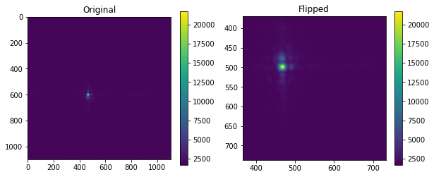

```python
ks.flip_image(zoom=3,
              estimate_only=False,
              plot_progress = True)
```

### Zero-padding and centering

This method centres Fourier image by finding local maximal within a specified region of interest (ROI). This methods suits well for centering purposes because Fourier images have multiple blobs that can be easily located. It is also assumed that one of these blobs is located exactly in the middle of the computational domain.

Note that this is a temporary solution chosen to handle images at hand. In general, Fourier images may be absolutely arbitrary and centering by localisation of local maxima may not be useful in every case.

> The image can be centred using `centre_image`method of `KSpaceImage`class.

```python
print(ks.centre_image.__doc__)
```

```
        Centers the Fourier-domain image whose centre is located at one of its local maxima
        Completes zero-padding of the original image to a specified linear number of pixels

        ---
        Parameters
        ---
        roi: tuple, optional
            Region of interest (ROI) used to search for local maxima.
            Default is (0,10,0,10).
        centre: tuple, optional
            Centre of the image.
            Default is (1,1), which must be changed by user once the centre of the image (one of the local maxima) is found.
        gaussian_filter : bool, optional
            Apply Gaussian filter to filter noise
            Default is False
        sigma : float, optional
            Standard deviation of a Gaussian filter
            Defailt is 1.0
        min_distance, int, optional
            Minimal distance between the local maxima
            Must be tuned by user to make the search most effective.
            Default is 10.
        threshold_abs: float, optional
            Minimum intensity of peaks.
            Default is 0.
        num_peaks: int, optional
            Maximum number of peaks.
            When the number of peaks exceeds num_peaks, return num_peaks peaks based on highest peak intensity.
            Default is 1.
        npixels_pad: int, optional
            Linear number of pixels in the zero-padded Fourier-domain image.
            Need be set to the one in the zero-padded object-domain image after it was resampled.
            Default is 2000.
        zoom: int, optional
            Zoom factor to zoom into the plot
            Default is 1 (no zoom)
        estimate_only: bool, optional
            False will irreversibly centre the image using local_max_coordinates specified in 'centre' argument
            True will only find the local_max_coordinates of local maxima
            Default is True.
        plot_progress: bool, optional
            Plot centred image for estimate_only = False.
            Default is False
```

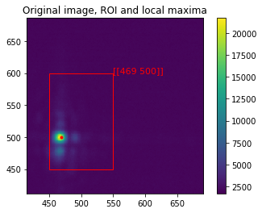

```python
ks.centre_image(estimate_only = True,
                centre = (469, 500),
                roi=(450,450,550,600),
                min_distance = 5,
                threshold_abs = 5000,
                num_peaks = 1,
                zoom = 4,
                npixels_pad = 2564,
                plot_progress = True)
```

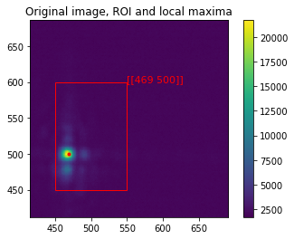

```
Fourier domain: Input image was padded to  2564 X 2564 pixels and centred.
```

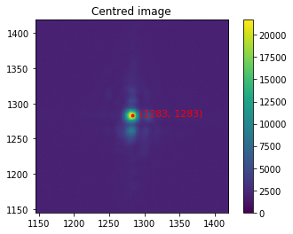

```python
ks.centre_image(estimate_only = False,
                centre = (469, 500),
                roi=(450,450,550,600),
                min_distance = 5,
                threshold_abs = 5000,
                num_peaks = 1,
                zoom = 4,
                npixels_pad = 2564,
                plot_progress = True)
```

> Optionally, the image can be centred manually by specifying the coordinates of its centre using `centre_image_manually`method: `ks.centre_image_manually(manual_centroid=(469, 500), npixels_final=2000`

### Subtraction of background

Similarly, we assume that the noise distribution is quasi-constant throughout the whole Fourier-domain image. The background is subtracted using `subtract_background`method of class `KSpaceImage`.

```
Fourier domain: Plotted in log scale
```

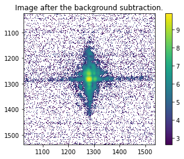

```
Fourier domain: Background of 2050 counts has been subtracted.
```

```python
ks.subtract_background(counts = 2050,
                       estimate_only=False,
                       zoom = 5,
                       log_scale = True,
                       plot_progress = True)
```

### Renormalisation (Parseval's theorem)

Now when both images are correctly sampled and have equal linear number of pixels $N$, we must renormalise one of them to fulfill Parseval's theorem:

$\sum\limits_{i = 0}^{N-1}\sum\limits_{j=0}^{N-1} |x[i,j]|^2 = \frac{1}{N^2} \sum\limits_{m=0}^{N-1}\sum\limits_{n=0}^{N-1} |X[m,n]|^2 $, (3)

where $i,j$ refer to the object space coordinates and $m,n$ to the Fourier space coordinates. We renormalise the Fourier-domain image.

> Compute energy in the object domain

```python
energy_rspace = sum(sum(rs.image))
print(energy_rspace)
```

```
464540396.0217333
```

> Renormalise in the Fourier domain.

```python
ks.renormalise_image(energy_rspace)
```

[output not shown]

## Saving processed images

> Processed images are saved using `save_as_tif` method of `RSpaceImage`and `KSpaceImage` classes. A user must enter a filename and specify a path to save the data. The data are saved as float32 data type.

```python
ks.save_as_tif(pathtosave=datapath, outputfilename="ks_processed_amplitude.tif")
```

```
Fourier domain: Image was saved in tif file under  /Users/Pavel/Documents/repos/PhaseRetrieval/docs/data/ks_processed_amplitude.tif
Fourier domain: Metadata was saved in csv file under  /Users/Pavel/Documents/repos/PhaseRetrieval/docs/data/ks_processed_amplitude.csv
```

```python
rs.save_as_tif(pathtosave=datapath, outputfilename="rs_processed_amplitude.tif")
```

```
Object domain: Image was saved in tif file under  /Users/Pavel/Documents/repos/PhaseRetrieval/docs/data/rs_processed_amplitude.tif
Object domain: Metadata was saved in csv file under  /Users/Pavel/Documents/repos/PhaseRetrieval/docs/data/rs_processed_amplitude.csv
```

The data are saved as float32 tif images. Its metadata are saved in csv files bearing the same names as the corresponding tif files.

# Phase retrieval

## Phase retrieval from two intensity measurements

Once object- and Fourier-domain images have been processed, they can be used for phase retrieval. Gerchberg-Saxton algorithm [Gerchberg-Saxton-1972] provides means of reconstructing object's phase from the modulus of the object's Fourier transform and the object's (low-resolution) image.

Schematic of the algorithm is shown below. The algorithm starts with a random phase distribution in Fourier domain and iterates between both domains by computing the discrete Fourier transform. Computed amplitudes in both domains are replaced with the corresponding measured ones and the phase distributions are kept the same.

The root mean square error serves as a quality metric in Fourier domain: $E = \frac{ \sum ||G| - |F||^2 }{\sum |F|^2}$ [Fienup-1997], where $|G|$ is the modulus of computed data in Fourier domain and $|F|$ is the measured amplitude. The summation is over all pixels.

[figure not shown]

## Oversampling requirements

Solution of the phase problem requires the fulfillment of the oversampling condition [Miao-1998]. The intensity of the light field scattered off the object provides the amplitude of the Fourier transform of the object distribution:

\begin{equation} \left| F(m_1\Delta q, m_2\Delta q) \right| = \left| \sum\limits_{n_1=0}^{N-1} \sum\limits_{n_2=0}^{N-1} f(n_1 \Delta r, n_2 \Delta r) e^{-2\pi\mathbb{i}(m_1n_1 + m_2n_2)/N}\right|, (4) \end{equation}

where $n_1, n_2 = 0,1,2,...,N-1$ are the sample numbers in the object domain and $m_1, m_2 = 0,1,2,...,N-1$ are the sample numbers in the Fourier domain. $f$ denotes complex-valued object and $F$ is its Fourier transform. $\Delta r$ and $\Delta q$ are the samples in object and Fourier domains, respectively, connected as $\Delta r \Delta q = \frac{1}{N}$.

Where $N$ is a linear number of pixels. Fourier-domain distribution (non-zero-valued pixels within the field of view) is sampled with $N_{FF}\times N_{FF}$ pixels. If the Fourier distribution is not zero-padded, then $N=N_{FF}$ and $N > N_{FF}$ otherwise. Object-distribution then has the same linear number of pixels (non-zero-valued pixels) is sampled with $N_{oo} \times N_{oo}$ pixels (object distributions are typically confined so that $N_{oo} < N$).

Phase retrieval is equivalent to the solution of the system of equations (4). And to solve this system of equations uniquely, the number of equations must exceed the number of unknowns.

#### Complex-valued object distribution, only Fourier amplitude is known

In case of a complex-valued object distribution, when only the Fourier amplitude distribution is known, there are $N_{FF}^2$ equations and $2N_{oo}^2$ unknowns (the factor 2 accounts for the real and imaginary parts of the object distribution). To solve the system of equations (4) uniquely, the number of known variables must exceed the number of unknown variables:

\begin{equation} N_{FF}^2 > 2N_{oo}^2. \end{equation}

[Miao-1998] defined the so-called oversampling ratio as the ratio between the total (non-zero-valued) pixel number and the number of pixels with unknown values:

\begin{equation} \sigma = \frac{\text{Total pixel number}}{\text{Number of unknown pixels}} = \frac{N_{FF}^2}{N_{oo}^2} \end{equation}

In case of a complex-valued object distribution, the so-called linear oversampling condition then reads as $\mathbb{O} = \sqrt{\sigma} > \sqrt{2}$.

#### Complex-valued object distribution, amplitudes in both Fourier and object domains are known

In case of a complex-valued object distribution when both Fourier and object amplitude distributions are known, the number of equations stays ulaltered and is equal to $N_{FF}^2$. The number of unknowns is reduced to $N_{oo}^2$.

To solve the system of equations (4) uniquely, the number of known variables must exceed the number of unknown variables:

\begin{equation} N_{FF}^2 > N_{oo}^2. \end{equation}

In this case, the linear oversampling ratio becomes $\mathbb{O} = \sqrt{\sigma} > 1$.

## Algorithm 1: Gerchberg-Saxton algorithm

> Import necessary packages; set `datapath` and `sourcepath`. Datapath contains object- and Fourier-domain data. Sourcepath contains the source code.

```python
import sys,os
import shutil, glob

datapath = '/Users/Pavel/Documents/repos/PhaseRetrieval/docs/data'
sourcepath = '/Users/Pavel/Documents/repos/PhaseRetrieval/'

sys.path.insert(0,sourcepath)
sys.path.insert(0,datapath)
```

> Import `phaseretrieval` method of `PhaseRetrieval`class and change the directory to the sourcepath (needed only in jupyter notebook, otherwise setting the paths suffice)

```python
from PhaseRetrieval.classes.phaseretrieval import PhaseRetrieval
os.chdir(sourcepath)
```

> Initialise `PhaseRetrieval`class and use previously saved processed images as inputs.

```python
#initialise phase retrieval class
pr = PhaseRetrieval(filename_rspace=os.path.join(datapath,"rs_processed_amplitude.tif"),
                    filename_kspace=os.path.join(datapath,"ks_processed_amplitude.tif"))
```

```
file type is tif
object-domain data were read as  /Users/Pavel/Documents/repos/PhaseRetrieval/docs/data/rs_processed_amplitude.tif

object-domain metadata were read as  /Users/Pavel/Documents/repos/PhaseRetrieval/docs/data/rs_processed_amplitude.csv

file type is tif
Fourier-domain data were read as  /Users/Pavel/Documents/repos/PhaseRetrieval/docs/data/ks_processed_amplitude.tif
```

Prior to application of phase retrieval algorithms, it makes sense to check if the oversamping ratio is fulfilled. The linear oversampling ratio must exceed *$\sqrt{1}$* for 2D data *in case when both amplitude- and Fourier-domain images are available*.

> This can be done using `check_oversampling_ratio`method of `PhaseRetrieval`class. Set the argument `extrapolation`to `False`. The method also prints out the metadata of the object-domain image.

```python
pr.check_oversampling(extrapolation = False)
```

```
Wavelength of light, m                                             8.8e-07
Field of view, deg                                                      17
Number of pixels within the field of view                              363
Linear size of the object, m                                        0.0001
Pixel size object domain, m                                       4.26e-07
Linear number of pixels in the zero-padded real-space image           2000
Image centred and padded?                                              yes
Apodization filter applied?                                            yes
Parseval's theorem fulfilled?                                          NaN
Background subtracted?                                                 yes
Pixel size Fourier domain, 1/nm                                5.75077e+12
Pixel size object domain from padded Fourier data, 1/nm            546.291
dtype: object
linear oversampling ratio =  10.925817883195393
linear oversampling condition is fulfilled
```

The oversampling ratio exceeds $\sqrt{1}$ and the data thus can be used in Gerchberg-Saxton algorithm, which is implemented in `gerchberg_saxton`method of `PhaseRetrieval`class.

> The arguments `gs_steps` and `plot_progress`set the number of iterations and allow to display the progress each `plot_every_kth_iteration` iteration, respectively. Here, for demonstration purposes, we set `gs_steps=10`. In reality, from hundreds to thousands of iterations may be required.

The RMS error in Fourier domain decreases with each iteration as expected.

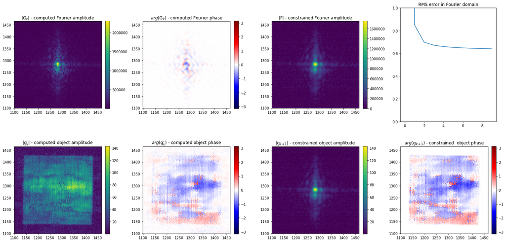

```
  completed
```

```python
pr.gerchberg_saxton(gs_steps = 10, plot_progress = True, plot_every_kth_iteration = 2, zoom = 7)
```

Upon completeion, reconstructed images can be saved as csv files. **Because phase images may contain negative-valued pixels, saving in csv format preserves these negative pixel values by default.** Saving in tif with default parameters leads to the loss of negative values.

> Set `Fourier_amplitude`, `Fourier_phase`, `object_amplitude`, `object_phase` to `True` to save reconstructed Fourier amplitude, Fourier phase (top left corner in Fig. above), object amplitude and object phase images (bottom right corner in Fig. above), respectively.

```python
pr.save_as_csv(filename="rs35ks35",
                pathtosave=datapath,
                Fourier_amplitude = True,
                Fourier_phase=True,
                object_amplitude=True,
                object_phase=True)
```

```
Fourier amplitude saved as  rs35ks35_Fourier_amplitude_163986000_20201001_084836.csv
Fourier phase saved as  rs35ks35_Fourier_phase_163986000_20201001_084836.csv
object amplitude saved as  rs35ks35_object_amplitude_163986000_20201001_084836.csv
object phase saved as  rs35ks35_object_phase_163986000_20201001_084836.csv
```

Filenames will indicate the corresponding saved image type (i.e. _object*phase*), followed by reciprocal space error recorded at the last iteration of the retrieval algorithm, date (YYYYMMDD) and time (HHMMSS). The error is given in format (1X000), where X are for digits of the decimal part of the error.

## Algorithm 2: Gerchberg-Saxton algorithm with extrapolation

In the example above, the object distribution is physically confined to the area sampled with $N_{oo}\times N_{oo}$ pixels and spatial extent of its diffraction pattern is limited by the field of view of the imaging system. To fulfill the requirements of the discrete Fourier transform, equation (1), the images were by re-sampled and zero-padded.

The spectrum of a size-limited object is infinite. Per definition, the discrete Fourier transform assumes the periodicity of the functions in both domains with the periods given by the linear number of pixels along each dimension. While zero-padding of the object-domain image can be justified due to the spatial confinement of the object, zero-padding in Fourier domain appears to be rather unnatural because the spectrum of the confined object distribution is infinitely extended and thus must not be truncated.

It is thereby makes sense to perform extrapolation of Fourier-domain data. Extrapolation of diffraction patterns in coherent diffraction imaging was suggested by [Latychevskaia-2015]. Here we follow the procedure described by Latychevskaia and co-workers.

We declare all zero-valued pixels in Fourier domain (including those which were set to zero upon the subtraction of the quasi-constant background) to be missing. The ratio between the number of missing pixels $N_\text{missing}$ and total pixel number $N_\text{total}$ is

\begin{equation} f = \frac{N_\text{missing}}{N_\text{total}}. \end{equation}

For zero-padded Fourier data, $N_\text{total} = N^2$. In object domain, there are $N_{oo}^2$ unknowns (object phases). Total number of measured (non-zero-valued) pixels is then $(1-f)N^2$. To solve the phase problem uniquely, the number of knowns must exceed the number of knowns.

\begin{equation} (1-f)N^2 > N_{oo}^2, \end{equation}

or, in terms of the linear oversampling ratio, $\mathbb{O}$, $f < 1 - \frac{1}{\mathbb{O}^2}$.

**Example**

For $\mathbb{O} = 10.9$, we obtain f < 0.9916. Which means that even less than $1 \%$ of all Fourier domain pixels are enough to reconstruct both the object distribution and the missing pixel values in Fourier domain. In reality, however, the quality of the reconstruction heavily degrades when $f$ is high (i.e. higher than 0.6-0.7 [Latychevskaia-2019].)

Gerchberg-Saxton algorithm with extrapolation implemented in `gerchberg_saxton_extrapolation`method of `PhaseRetrieval`class.

> The arguments `gs_steps` and `plot_progress`set the number of iterations and allow to display the progress each `plot_every_kth_iteration` iteration, respectively. Here, for demonstration purposes, we set `gs_steps=6`. In reality, from hundreds to thousands of iterations may be required.

The RMS error in Fourier domain decreases with each iteration as expected.

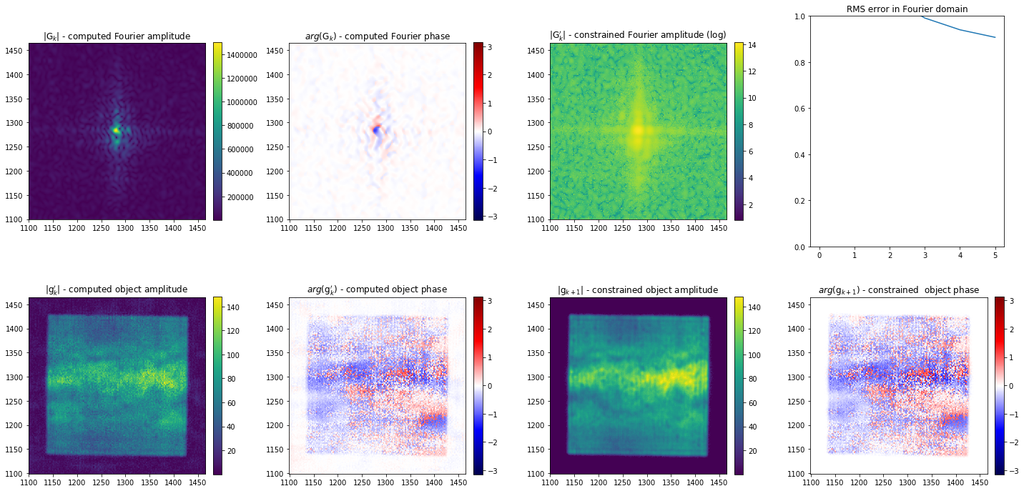

```
  completed
```

```python
pr. gerchberg_saxton_extrapolation(gs_steps = 6, plot_progress = True, plot_every_kth_iteration = 2, zoom = 7)
```

# Automated procedures

The whole phase retrieval procedure demonstrated above (i.e. image processing, Gerchberg-Saxton algorithm and image alignment) can be run unattended and asynchronously, without human supervision, as a batch job on a linux cluster. The following sections show examples of scripts that can be used in such shell scripts.

## Phase retrieval from two intensity measurements

### Step 1: Image processing and generation of object and Fourier domain images with different linear number of pixels and different levels of subtracted noise

`preprocessing_script` of the `PhaseRetrieval` framework allows to obtain processed images with different widths of the zero-padded regions (thus for different linear number of pixels) and different levels of subtracted noise in both domains. Varying the linear number of pixels changes the number of missing pixels to be recovered in the Gerchberg-Saxton algorithm with extrapolation and thus, together with different levels of subtracted noise, may have an impact on the quality of the reconstructions.

We consider images having the same linear number of pixels and the same level of subtracted noise to be "of the same type".

> Import necessary packages, set `datapath` and `sourcepath`. Datapath contains object- and Fourier-domain data. Sourcepath contains the source code.

```python
import sys,os
import shutil, glob

datapath = '/Users/Pavel/Documents/repos/PhaseRetrieval/docs/data'
sourcepath = '/Users/Pavel/Documents/repos/PhaseRetrieval/'
#datapath = '/Users/Pavel/Documents/temp/on pc/phase_retrieval/BEC/20190124_S#16_20180122_IR792_080mM_800nm_original_AWESOME/20190124_rsp04_ksp16_050fs/35'

sys.path.insert(0,sourcepath)
sys.path.insert(0,datapath)
```

> Import `phaseretrieval` method of `PhaseRetrieval`class and change the directory to the sourcepath (needed only in jupyter notebook, otherwise setting the paths suffice)

```python
from PhaseRetrieval.classes.phaseretrieval import PhaseRetrieval
os.chdir(sourcepath)
```

> Using `preprocessing_script` complete image processing for different linear number of pixels and noise. The function saves processed images under the specified datapath.

```python
from PhaseRetrieval.scripts.scripts import preprocessing_script

preprocessing_script(datapath = datapath,
                       rs_filename = "rs35.csv",
                       ks_filename = "ks35.csv",
                       delimiter = '\t',
                       lambd=880e-9,
                       rs_pixelsize=340e-9,
                       rs_linear_object_size=100e-6,
                       ks_fieldofview = 17,
                       ks_npixels = 500,
                       ks_centre=(467, 500),
                       ks_gaussian_filter=True,
                       ks_sigma=1,
                       ks_roi=(400, 400, 550, 550),
                       ks_min_distance=5,
                       ks_threshold_abs=5000,
                       ks_num_peaks=5,
                       npixels_pad_iter = [2000],
                       ks_noise_iter = [1900, 2000, 2100],
                       rs_noise_iter = [2500],
                       suppress_print = True)
```

> Plot the result for the last data set

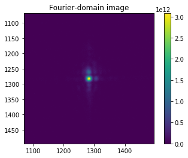

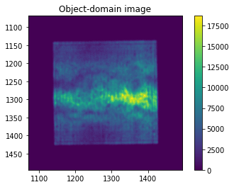

```python
ks.plot_image(zoom=6)
rs.plot_image(zoom=6)
```

### Step 2: Apply Gerchberg-Saxton algorithm with extrapolation to the processed images

> Unattended reconstruction by GS algorithm with extrapolation can be done by means of `gerchberg_saxton_extrapolation_script`.

```python
from PhaseRetrieval.scripts.scripts import gerchberg_saxton_extrapolation_script
print(gerchberg_saxton_extrapolation_script.__doc__)
```

```
    Script to launch GS algorithm with extrapolation and save reconstructed images.
    Customized for the case when image are saved in several folders (e.g. each containing images with different parameters)
    Reconstructed images are saved as csv (no metadata) in individual folders containing images of the same kind (e.g. equal number of pixels)
    ---
    Parameters
    ---
    files_extension: {"*.tif", "*.csv"}
        Extension of raw images.
        Must be chosen from the given set of extensions, i.e. either "*.tif" or "*.csv".
        Default is "*.tif".
    ---Initialisation of PhaseRetrieval class-related:---
    datapath: str
        Path used to load data (the same as used to load raw data).
        Default is None.
    rs_prefix: str
        Prefix common to names of the files containing object-domain images.
        Default is None.
    ks_filename: str
        Prefix common to names of the files containing Fourier-domain images.
        Default is None.
    ---
    ---PhaseRetrieval.gerchberg_saxton_extrapolation method-related:---
    gs_steps: int
        Number of iterations in GS algorithm
        Default is None.
    plot_progress : bool, optional
        False will prevent algorithm from plotting the progress.
        True will plot the progress of the algorithm.
        Default is False.
    plot_every_kth_iteration : int, optional
        Plot the progress each k-th iteration, where k=plot_every_kth_iteration
        Default is 1.
    zoom: int, optional
        Zoom factor to zoom into the 2D plot
        Default is 1 (no zoom)
    ---
    ---PhaseRetrieval.save_as_tif method-related:---
    Fourier_amplitude : bool, optional
        If set to True, constrained Fourier amplitude will be saved
        Default is True
    Fourier_phase : bool, optional
        If set to True, constrained(=computed) Fourier phase will be saved
        Default is True
    object_amplitude : bool, optional
        If set to True, computed object amplitude will be saved
        Default is True
    object_phase : bool, optional
        If set to True, computed object phase will be saved
        Default is True
    ---
    rec_number : int, optional
        Number of times the algorithm is run with random initial phases = number of reconstructions
        Default is 1.
    print_progress : bool, optional
        False will block print calls.
        True will let print calls to be displayed.
        Default is False.
```

```python
gerchberg_saxton_extrapolation_script(datapath = datapath,
                                   rs_prefix = "rs35",
                                   ks_prefix = "ks35",
                                   files_extension = "*.tif",
                                   gs_steps = 1,
                                   plot_progress = True,
                                   plot_every_kth_iteration = 10,
                                   zoom=6,
                                   Fourier_amplitude = True,
                                   Fourier_phase = True,
                                   object_amplitude = True,
                                   object_phase = True,
                                   filename = "rs35_ks35_",
                                   rec_number = 2,
                                   print_progress = True)
```

```
file type is tif
object-domain data were read as  /Users/Pavel/Documents/repos/PhaseRetrieval/docs/data/Ntot2000rsnoise2500ksnoise1900_rs35_amplitude.tif

object-domain metadata were read as  /Users/Pavel/Documents/repos/PhaseRetrieval/docs/data/Ntot2000rsnoise2500ksnoise1900_rs35_amplitude.csv

file type is tif
Fourier-domain data were read as  /Users/Pavel/Documents/repos/PhaseRetrieval/docs/data/Ntot2000rsnoise2500ksnoise1900_ks35_amplitude.tif

file type is tif
object-domain data were read as  /Users/Pavel/Documents/repos/PhaseRetrieval/docs/data/Ntot2000rsnoise2500ksnoise2000_rs35_amplitude.tif

object-domain metadata were read as  /Users/Pavel/Documents/repos/PhaseRetrieval/docs/data/Ntot2000rsnoise2500ksnoise2000_rs35_amplitude.csv

file type is tif
Fourier-domain data were read as  /Users/Pavel/Documents/repos/PhaseRetrieval/docs/data/Ntot2000rsnoise2500ksnoise2000_ks35_amplitude.tif

file type is tif
object-domain data were read as  /Users/Pavel/Documents/repos/PhaseRetrieval/docs/data/Ntot2000rsnoise2500ksnoise2100_rs35_amplitude.tif

object-domain metadata were read as  /Users/Pavel/Documents/repos/PhaseRetrieval/docs/data/Ntot2000rsnoise2500ksnoise2100_rs35_amplitude.csv

file type is tif
Fourier-domain data were read as  /Users/Pavel/Documents/repos/PhaseRetrieval/docs/data/Ntot2000rsnoise2500ksnoise2100_ks35_amplitude.tif
```

For each type of the processed images (i.e. images having the same linear number of pixels and the level of subtracted noise), `gerchberg_saxton_extrapolation_script`generates a directory, in which it copies the corresponding object- and Fourier-domain images and saves reconstructed distributions. The output file structure under `datapath` looks as follows:

- Amplitude, object domain, raw data (typically .tif)
- Amplitude, Fourier domain, raw data (typically .tif)
- Amplitude, object domain, image type 1 (saved as .tif)
- Amplitude, object domain, metadata of image type 1 (saved as .csv)
- Amplitude, Fourier domain, image type 1 (saved as .tif)
- Amplitude, Fourier domain, metadata of image type 1 (saved as .csv)
- Folder with copies images of type 1 and reconstructed images:
  - Amplitude, object domain, image type 1 (saved as .tif)
  - Amplitude, Fourier domain, image type 1 (saved as .tif)
  - Reconstructed phase, object domain, using images type 1, reconstruction 1 (saved as .csv)
  - Reconstructed phase, object domain, using images type 1, reconstruction 2 (saved as .csv)
  - ...
  - Reconstructed phase, object domain, using images type 2, reconstruction `rec_number` (saved as .csv)
- Amplitude, object domain, image type 2
- Amplitude, object domain, metadata of image type 2 (saved as .csv)
- Amplitude, Fourier domain, image type 2
- Amplitude, Fourier domain, metadata of image type 2 (saved as .csv)
- Folder with copies images of type 2 and reconstructed images:
  - Amplitude, object domain, image type 2 (saved as .tif)
  - Amplitude, Fourier domain, image type 2 (saved as .tif)
  - Reconstructed phase, object domain, using images type 2, reconstruction 1 (saved as .csv)
  - Reconstructed phase, object domain, using images type 2, reconstruction 2 (saved as .csv)
  - ...
  - Reconstructed phase, object domain, using images type 2, reconstruction `rec_number` (saved as .csv)

...

Reconstructed images are saved with self-descriptive strings in their filenames, such as `_object_phase_`or `_Fourier_amplitude_`.

### Step 3: Alignment of reconstructed phase images

```python
from PhaseRetrieval.scripts.scripts import phase_alignment_gerchberg_saxton_script
#print(help(phase_alignment_gerchberg_saxton_script))
```

> In the following, `phase_prefix` argument is set to `"_object_phase_"`, although one can also align Fourier-domain phase images by setting it to `"_Fourier_phase"`.

```python
phase_alignment_gerchberg_saxton_script(datapath = datapath,
                                 folder_prefix = "Ntot",
                                 amplitude_prefix = "rs35_",
                                 phase_prefix = "_object_phase_",
                                 delimiter = '\t',
                                 num_files_to_align=3,
                                 ref_coordinates = None,
                                 symmetric_phase = True,
                                 plot_progress = True,
                                 plot_every_kth_iteration = 1,
                                 zoom = 10,
                                 print_progress = True)
```

> Plot reconstructied images

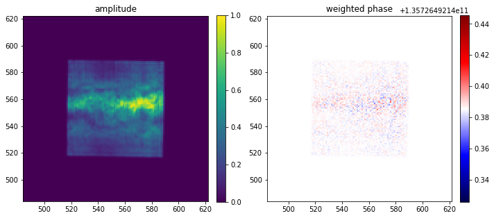

```
/Users/Pavel/Documents/temp/on pc/phase_retrieval/BEC/20190124_S#16_20180122_IR792_080mM_800nm_original_AWESOME/20190124_rsp04_ksp16_050fs/35/Ntot1110rsnoise2500ksnoise1900_rs35_amplitude.tif
```

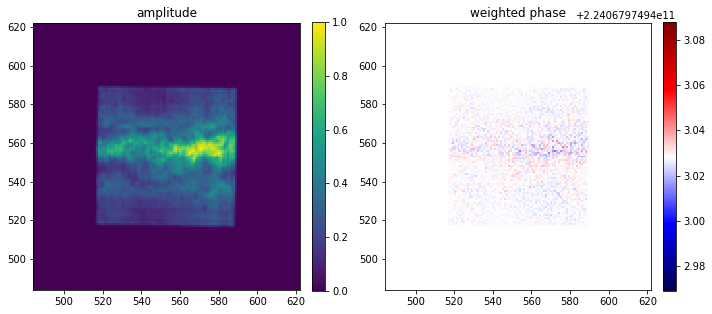

```
/Users/Pavel/Documents/temp/on pc/phase_retrieval/BEC/20190124_S#16_20180122_IR792_080mM_800nm_original_AWESOME/20190124_rsp04_ksp16_050fs/35/Ntot1110rsnoise2500ksnoise2000_rs35_amplitude.tif
```

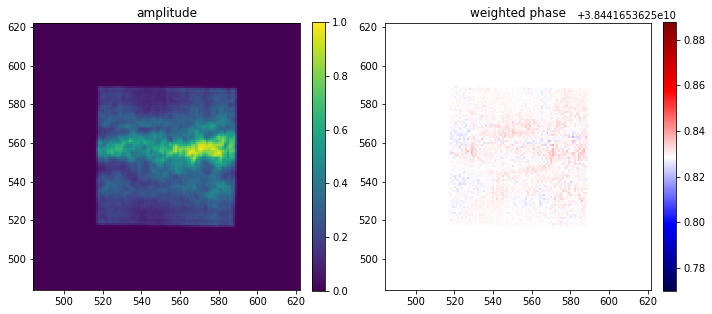

```
/Users/Pavel/Documents/temp/on pc/phase_retrieval/BEC/20190124_S#16_20180122_IR792_080mM_800nm_original_AWESOME/20190124_rsp04_ksp16_050fs/35/Ntot1110rsnoise2500ksnoise2100_rs35_amplitude.tif
```

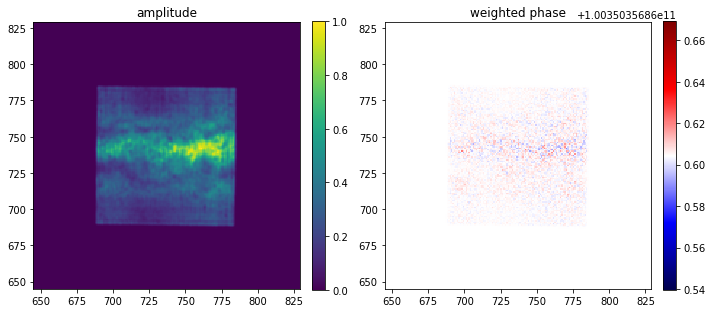

```
/Users/Pavel/Documents/temp/on pc/phase_retrieval/BEC/20190124_S#16_20180122_IR792_080mM_800nm_original_AWESOME/20190124_rsp04_ksp16_050fs/35/Ntot1500rsnoise2500ksnoise1900_rs35_amplitude.tif
```

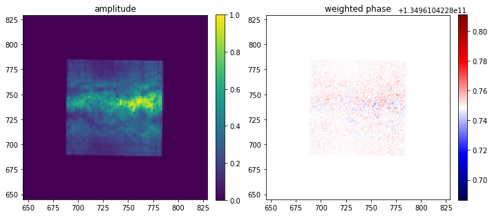

```
/Users/Pavel/Documents/temp/on pc/phase_retrieval/BEC/20190124_S#16_20180122_IR792_080mM_800nm_original_AWESOME/20190124_rsp04_ksp16_050fs/35/Ntot1500rsnoise2500ksnoise2000_rs35_amplitude.tif
```

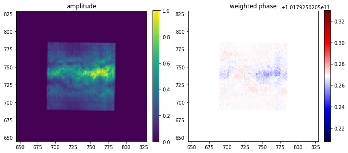

```
/Users/Pavel/Documents/temp/on pc/phase_retrieval/BEC/20190124_S#16_20180122_IR792_080mM_800nm_original_AWESOME/20190124_rsp04_ksp16_050fs/35/Ntot1500rsnoise2500ksnoise2100_rs35_amplitude.tif
```

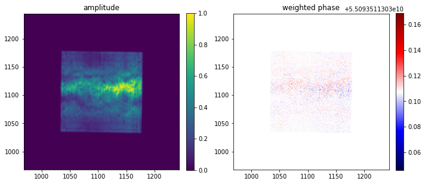

```
/Users/Pavel/Documents/temp/on pc/phase_retrieval/BEC/20190124_S#16_20180122_IR792_080mM_800nm_original_AWESOME/20190124_rsp04_ksp16_050fs/35/Ntot2000rsnoise2500ksnoise1900_rs35_amplitude.tif
```

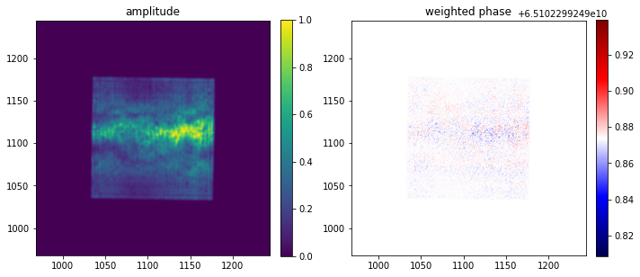

```
/Users/Pavel/Documents/temp/on pc/phase_retrieval/BEC/20190124_S#16_20180122_IR792_080mM_800nm_original_AWESOME/20190124_rsp04_ksp16_050fs/35/Ntot2000rsnoise2500ksnoise2000_rs35_amplitude.tif
```

```python
import os
from PhaseRetrieval.modules.postprocessing import plot_reconstruction

datapath = '/Users/Pavel/Documents/temp/on pc/phase_retrieval/BEC/20190124_S#16_20180122_IR792_080mM_800nm_original_AWESOME/20190124_rsp04_ksp16_050fs/35/'

amplitude_filenames =  [os.path.abspath(os.path.join(datapath, p)) for p in os.listdir(datapath) if p.endswith(('rs35_amplitude.tif'))]
phase_filenames =  [os.path.abspath(os.path.join(datapath, p)) for p in os.listdir(datapath) if p.endswith(('rs35_phase.csv'))]
#print(amplitude_filenames)
#print(phase_filenames)

for amplitude_filename, phase_filename in zip(amplitude_filenames, phase_filenames):
    plot_reconstruction(amplitude_filename = amplitude_filename, phase_filename = phase_filename, delimiter = '\t', zoom = 8)
    print(amplitude_filename)
```

# References

[Fienup-1997] J. R. Fienup. Invariant error metrics for image reconstruction . Appl. Opt. 36, 8352–8357 (1997).

[Gerchberg-Saxton-1972] R. W. Gerchberg and W. O. Saxton, "A practical algorithm for the determination of the phase from image and diffraction plane pictures,” Optik 35, 237 (1972)

[Latychevskaia-2015] T. Latychevskaia et al., Imaging outside the box: Resolution enhancement in X-ray coherent diffraction imaging by extrapolation of diffraction patterns Appl. Phys. Lett. 107, 183102 (2015)

[Latychevskaia-2019] T. Latychevskaia, Reconstruction of missing information in diffraction patterns and holo452, 56-67 (2019)

[Miao-1998] J.W. Miao, D. Sayre, H.N. Chapman, Phase retrieval from the magnitude of the Fourier transforms of nonperiodic objects, J. Opt. Soc. Am. A, 15 (1998) 1662–1669.